# Data analysis of CO2 emissions and class structure

Michael Lindner

5/12/2022

# Preliminaries: Version control

For exact reproducibility of our results we use the package manager `renv` to keep track of the versions of all packages used.

To reproduce our analysis, install `renv` then use `renv::activate()` to activate the environment specified in the lockfile. You might have to use `renv::hydrate()` to install required packages as well. Afterwards you can run the R code as you would normally do.

Troubleshooting: `renv::restore()`

# Preprocessing: extracting the necessary qualitative data from the various datasets

We begin by loading libraries…

```r
library("haven")
library("dplyr")
library("readxl")
library("openxlsx")
library(tidyr)
library(formattable)
library(knitr)
library("survey")
library(viridis)
library(mitools)
library(labelled)
library(htmltools)
library(webshot2)
```

All needed data has been added to the lcf_mi file in other scripts

```r
mil <- readRDS("../data/lcf_milper.rds")
```

## Survey

We don’t have PSU and Strata, still we can use the weights for the survey. Here we use the original data with missing values in HighEdHH.

```r
lcf <- mil$`0`
svy <- svydesign(ids = ~1,  weights = lcf$weighta, data = lcf)
```

## Middle classes

Start by getting the (weighted) Median income

```r
median_income = svyquantile(~EqIncDOp, svy, c(.5))$EqIncDOp[1]
```

```r
assign_reckwitz_class <- function(x, upper_threshold = 2.5) {
  # Since accessing columns by name in mutate is not so easy
  # Assuming x[1] is EqIncDOp and x[2] is HighEdHH
  if (x[1] <= 0.7 * median_income) { return("lower") }
  if (x[1] >  upper_threshold * median_income) { return("upper") }
  if (is.na(x[2])) { return(NA) }
  if (x[2] == 1) { return("new middle") }
  if (x[2] == 10) { return("new middle") } # student households
  return("old middle")
}

#change this for sensitivity analysis
upper_threshold = 2

mil <- lapply(mil, function(x) x %>% rowwise %>% mutate(ReckwitzClass = factor(assign_reckwitz_class(c(EqIncDOp,HighEdHH), upper_threshold = upper_threshold), levels = c("lower", "old middle", "new middle", "upper"))))
```

How many Households are affected by the imputation

```r
sum(is.na(mil$`0`$ReckwitzClass)) + sum(mil$`0`$ReckwitzClass != mil$`1`$ReckwitzClass |
      mil$`0`$ReckwitzClass != mil$`2`$ReckwitzClass |
      mil$`0`$ReckwitzClass != mil$`3`$ReckwitzClass |
      mil$`0`$ReckwitzClass != mil$`4`$ReckwitzClass |
      mil$`0`$ReckwitzClass != mil$`5`$ReckwitzClass |
      mil$`0`$ReckwitzClass != mil$`6`$ReckwitzClass, na.rm=T)
```

```
## [1] 885
```

For ease of access to the unimputed data, recreate the svy object

```r
lcf <- mil$`0`
svy <- svydesign(ids = ~1,  weights = lcf$weighta, data = lcf)
svyby(~EqIncDOp, ~ReckwitzClass, svy, svymean)
```

```
##            ReckwitzClass  EqIncDOp        se
## lower              lower  185.7170  1.698474
## old middle    old middle  442.3514  3.547414
## new middle    new middle  512.4303  4.103527
## upper              upper 1115.0960 20.656823
```

Now create a survey object with all multiple imputations. With `mitools` statistics of different subset can be combined. This should be used for all analysis.

```r
svymi <- svydesign(ids = ~1,  weights = lcf$weighta, data = imputationList(mil[2:7]))
```

# Computing GHG for COICOP categories

First we load the bridging table:

```r
bridged <- read.xlsx("../data/bridging_matrix_edited.xlsx") %>% slice(2:n())
B <- bridged %>% filter(USE==TRUE)
rm(bridged)
```

We define functions to conveniently access COICOP (sub-)categories

```r
# This function returns all used LCF codes that belong to a specific coicop (sub-) category

coicop_to_lcf <- function(category) {
  if (category %in% B$COICOPCODE)  {
    return(B %>% filter(COICOPCODE == category)
         %>% select(LCFCODE) %>% unlist%>% as.character)
  } else {
  category = paste(category,".",sep="")
  return(B %>% filter(startsWith(COICOPCODE,category))
         %>% select(LCFCODE) %>% unlist%>% as.character)
  }
}
coicop_to_xp_formula <- function(category) {
  # Division by number of persons in HH (A049)
if (length(category) != 1)
{return(as.formula(paste("~I((", paste(category, collapse = " + "),")/A049)")))}
else{
 return(as.formula(paste("~I((", paste(coicop_to_lcf(category), collapse = " + "),")/A049)")))}
}

coicop_to_ghg_formula <- function(category) {
 # Append "GHG_" to access GHG emissions instead of expenditures
 if (length(category) != 1) {
  cats <- paste("GHG_", category,  sep="")
 }
 else{
 cats <- paste("GHG_", coicop_to_lcf(category),  sep="")
 }
 # Division by number of persons in HH (A049)
 return(as.formula(paste("~I((", paste(cats, collapse = " + "),")/A049)")))
}
```

Now lets compute total CO2 for all 12 COICOP categories

```r
CO2_full <- sapply(as.character(c(1:12)), function(x) MIcombine(with(svymi, svyby(coicop_to_ghg_formula(x), ~ReckwitzClass,svymean))))

CO2 <- CO2_full[1,] %>% simplify2array
CO2_SE <- sapply(CO2_full[2,], function(x) sqrt(diag(x)))

CO2 <- t(CO2)

CO2 <- rbind(CO2, colSums(CO2))
row.names(CO2)[13] <- "Total"


CO2
```

```
##              lower  old middle  new middle       upper
## 1      18.43197515  22.9158843  20.5094035  25.7150885
## 2       0.45917681   0.5704889   0.4946912   0.7751082
## 3       2.27470103   3.3569538   3.4924106   6.1409893
## 4      55.92595918  58.8539392  53.2737940  71.0339446
## 5       2.59060592   5.0750269   4.9401327  11.4552160
## 6       2.49551840   3.5367272   4.0833353   4.0106103
## 7      28.78134867  58.2799669  67.9006686 108.1382133
## 8       0.76653896   1.0511529   1.1321145   1.3138608
## 9       6.89174723  11.4780298  12.1797498  19.9155885
## 10      0.08173863   0.4501285   0.6498771   2.3371209
## 11      4.96825214   9.8928674  11.2707205  20.3654785
## 12      3.75286485   6.9928179   7.7689455  11.7162400
## Total 127.42042696 182.4539837 187.6958432 282.9174588
```

And plot it

```r
png(paste("coicop_co2_classes_relative","_", upper_threshold ,"up.png", sep=""))

image(round(t(CO2) / rowSums(t(CO2)) * 200)  ,xaxt="n",yaxt="n",ylab="COICOP categories", col=rocket(256, direction= -1))
#image(t(CO2/ rowSums(CO2)) ,xaxt="n",yaxt="n",ylab="COICOP categories", col=rocket(256, direction= -1))
axis(side=1, at=c(0,0.33,0.66,1.0), labels=levels(lcf$ReckwitzClass))
axis(side=2, at=seq(0,1, 1/12), labels=row.names(CO2), las=2)
grid(nx=4,ny=13,col="black")
dev.off()
```

# Utilities for formattable plotting

This can be used for nicer plots later on.

```r
#' altbind(df1, SE_df1)
#'
#' Bind together two dataframes in alternating column order
#' Assumes the first on contains mean values, and the second standard errors
altbind <- function(df1,df2) {
  assertthat::assert_that(ncol(df1) == ncol(df2))
  assertthat::are_equal(rownames(df1),rownames(df2))
  df3 <- data.frame(df1[,1], df2[,1])
  cns <- c(colnames(df1)[1], "SE")
  for (i in 2:ncol(df1)) {
    df3 <- data.frame(df3, df1[,i], df2[,i])
    cns <- c(cns, colnames(df1)[i], paste("SE", paste(rep(" ",i-1), collapse = ""), sep=""))
    }
  colnames(df3) <- cns
  rownames(df3) <- rownames(df1)
  return(df3)
}
```

Saving needs this function and packages

```r
#library(htmltools)
#library(webshot2)
# Width by default 75% instead of 100%!!!
export_formattable <- function(f, file, width = "65%", height = NULL,
                               background = "white", delay = 0.2, zoom = 2)
{
  w <- as.htmlwidget(f, width = width, height = height)
  path <- html_print(w, background = background, viewer = NULL)
  url <- paste0("file:///", gsub("\\\\", "/", normalizePath(path)))
  webshot(url,
          file = file,
          selector = ".formattable_widget",
          zoom = zoom,
          delay = delay,
          vheight = 900)
}
```

```r
smallfont <- formatter("span", style = x ~ ifelse(TRUE, "font-size:10px", NA))
```

# T-Test utitiles

```r
# from the lodown package

MIsvyttest<-function(formula, design , ...){

    # the MIcombine function runs differently than a normal svyglm() call
    m <- eval(bquote(mitools::MIcombine( with( design , survey::svyglm(formula,family=gaussian()))) ) )

    rval<-list(statistic=coef(m)[2]/survey::SE(m)[2],
               parameter=m$df[2],
               estimate=coef(m)[2],
               null.value=0,
               alternative="two.sided",
               method="Design-based t-test",
               data.name=deparse(formula))

    rval$p.value <- ( 1 - pf( ( rval$statistic )^2 , 1 , m$df[2] ) )

    names(rval$statistic)<-"t"
    names(rval$parameter)<-"df"
    names(rval$estimate)<-"difference in mean"
    names(rval$null.value)<-"difference in mean"
    class(rval)<-"htest"

    return(rval)

}

MIsvyttest(I(HighEdHH==1)~ReckwitzClass, subset(svymi, ReckwitzClass == "new middle" | ReckwitzClass == "old middle"))
```

```
##
##  Design-based t-test
##
## data:  I(HighEdHH == 1) ~ ReckwitzClass
## t = 287.79, df = 614.3, p-value < 2.2e-16
## alternative hypothesis: true difference in mean is not equal to 0
## sample estimates:
## difference in mean
##          0.9869903
```

For the t-test formulae

```r
coicop_to_ttest_formula <- function(category) {
 # Append "GHG_" to access GHG emissions instead of expenditures
 if (length(category) != 1) {
  cats <- paste("GHG_", category,  sep="")
 }
 else{
 cats <- paste("GHG_", coicop_to_lcf(category),  sep="")
 }
 # Division by number of persons in HH (A049)
 return(as.formula(paste("I((", paste(cats, collapse = " + "),")/A049)~ReckwitzClass")))
}
```

# Summary Statistics

```r
summary_forms <- sapply(c("~I(HighEdHH==1)", "~EqIncDOp", "~I(Ten1<=2)", "~I(Gorx == 7)"), as.formula)

H_full <- sapply(summary_forms, function(x) MIcombine(with(svymi, svyby(x, ~ReckwitzClass,svymean))))


H_cts <- H_full[1,c(2)] %>% simplify2array %>% as.data.frame
H_cts[,1] <- H_cts[,1] * 52
H_cts <- H_cts %>% round(digits=2)
H_cts[,1] <- H_cts[,1] %>% round
colnames(H_cts) <- c("Equivalised Income")

H_fct <- (H_full[1,c(1,3,4)] %>% simplify2array %>% as.data.frame)[5:8,]
H_fct <- (H_fct * 100)  %>% round(digits=2)
colnames(H_fct) <- c("% academic degree", "% owning home", "% in London")
rownames(H_fct) <- rownames(H_cts)

H_cts_SE <- sapply(H_full[2,c(2)], function(x) sqrt(diag(x))) %>% as.data.frame
H_cts_SE[,1] <- H_cts_SE[,1] * 52
H_cts_SE <- H_cts_SE %>% round(digits=2)
H_cts_SE[,1] <- H_cts_SE[,1] %>% round
colnames(H_cts_SE) <- colnames(H_cts)
H_cts_SE <- data.frame(apply(H_cts_SE, c(1,2),function(x) paste("±", x, sep="")))

H_fct_SE <- (sapply(H_full[2,c(1,3,4)], function(x) sqrt(diag(x))) %>% as.data.frame)[5:8,]
H_fct_SE <- (H_fct_SE * 100) %>% round(digits=2)
colnames(H_fct_SE) <- colnames(H_fct)
rownames(H_fct_SE) <- rownames(H_cts_SE)
H_fct_SE <- data.frame(apply(H_fct_SE, c(1,2),function(x) paste("±", x, sep="")))

S_form <- altbind(data.frame( H_fct %>% select(1),
                              H_cts %>% select(1),
                              H_fct %>% select(2),
                              H_fct %>% select(3), check.names = FALSE),
                  data.frame( H_fct_SE %>% select(1),
                              H_cts_SE %>% select(1),
                              H_fct_SE %>% select(2),
                              H_fct_SE %>% select(3),check.names = FALSE))
```

```r
FT <- formattable(S_form, list(
  "% academic degree" = my_color_bar("violet",100, function(x) {x/100}),
  "SE" = smallfont,
  "Equivalised Income"= my_color_bar("tomato",100, proportion),
  "SE " = smallfont,
  "% owning home" = my_color_bar("orange",100, function(x) {x/100}),
  "SE  " = smallfont,
  "% in London"= my_color_bar("lightskyblue",100, function(x) {x/100}),
  "SE   " = smallfont
  ))

FT
```

|  | % academic degree | SE | Equivalised Income | SE | % owning home | SE | % in London | SE |
| --- | --- | --- | --- | --- | --- | --- | --- | --- |
| lower | 27.28 | ±1.8 | 9657 | ±88 | 43.48 | ±1.36 | 10.69 | ±0.99 |
| old middle | 0.00 | ±0 | 22533 | ±184 | 67.07 | ±1.33 | 7.61 | ±0.9 |
| new middle | 98.70 | ±0.34 | 25663 | ±207 | 77.09 | ±1.25 | 14.14 | ±1.11 |
| upper | 77.11 | ±2.47 | 57985 | ±1074 | 86.59 | ±1.85 | 26.56 | ±2.43 |

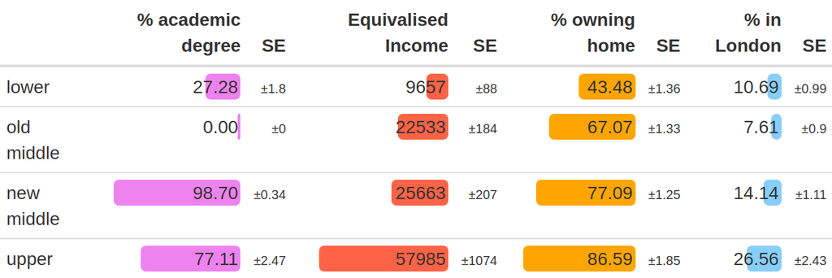

```r
export_formattable(FT,paste("summary.png", sep=""))
```

## HighEdHH in NMC not due to student households

```r
MIcombine(with(svymi, svyby(~I(HighEdHH==1), ~ReckwitzClass,svymean)))
```

```
## Multiple imputation results:
##       with(svymi, svyby(~I(HighEdHH == 1), ~ReckwitzClass, svymean))
##       MIcombine.default(with(svymi, svyby(~I(HighEdHH == 1), ~ReckwitzClass,
##     svymean)))
##                                     results           se
## lower:I(HighEdHH == 1)FALSE      0.72722584 1.796035e-02
## old middle:I(HighEdHH == 1)FALSE 1.00000000 5.363865e-17
## new middle:I(HighEdHH == 1)FALSE 0.01300975 3.429574e-03
## upper:I(HighEdHH == 1)FALSE      0.22885776 2.472855e-02
## lower:I(HighEdHH == 1)TRUE       0.27277416 1.796035e-02
## old middle:I(HighEdHH == 1)TRUE  0.00000000 0.000000e+00
## new middle:I(HighEdHH == 1)TRUE  0.98699025 3.429574e-03
## upper:I(HighEdHH == 1)TRUE       0.77114224 2.472855e-02
```

# Totals

```r
glm_formula <- lcf %>% colnames %>% grep("GHG_", . , value=TRUE) %>% paste(collapse = " + ") %>% paste("I((", . , ")/A049) ~ EqIncDOp + I(HighEdHH==1)", sep = "") %>% formula

lin <- with(svymi, svyglm(glm_formula))

# for (mod in lin) {show(summ(mod))}
```

```r
# Households
#pop_per_class <- MIcombine(with(svymi, svytotal(~ReckwitzClass)))
# Persons
pop_per_class <- MIcombine(with(svymi, svyby(~A049, ~ReckwitzClass, svytotal)))
H <- pop_per_class$coefficients %>% round
H_SE <- pop_per_class$variance %>% diag %>% sqrt
```

```r
total_co2_formula <- lcf %>% colnames %>% grep("GHG_", . , value=TRUE) %>% paste(collapse = " + ") %>% paste("~I(", . , ")", sep = "") %>% as.formula
co2_per_class <- MIcombine(with(svymi, svyby(total_co2_formula, ~ReckwitzClass, svytotal)))
```

[output not shown]

[output cut: 16 more lines]

[output not shown]

```r
S <- (co2_per_class$coefficients * 52 / 1e6) %>% round
S_SE <- ((co2_per_class$variance %>% diag %>% sqrt) * 52 / 1e6) %>% round
```

```r
leng = 512
png(paste("totals_per_class","_", upper_threshold ,"up.png", sep=""),height=leng,width=2*leng)

# Create data

dat <- cbind(H, S)
colnames(dat) <- c("Population", "CO2")
rownames(dat) <- c("lower", "old middle", "new middle", "upper")

# create color palette:
library(RColorBrewer)
coul <- brewer.pal(4, "Set2")

# Transform this data in %
data_percentage <- apply(dat, 2, function(x){x*100/sum(x)})

# Enable plotting outside
cfactor = 2.8
par(mar=c(3, 6, 3, 20), xpd=TRUE, cex.lab=cfactor, cex.axis=cfactor, cex.main=cfactor, cex.sub=cfactor, pty="m")

# Make a stacked barplot--> it will be in %!
bp <- barplot(data_percentage, col=coul, border="white", ylab="% of total")
legend("topright", legend=rev(rownames(dat)), fill=rev(coul), inset = c(-.41,0), box.col="white", cex=cfactor)


y_pop <- c(data_percentage[1,1]/2, sum(data_percentage[1:2,1]) - data_percentage[2,1]/2,
           sum(data_percentage[1:3,1]) - data_percentage[3,1]/2, sum(data_percentage[,1]))

y_pop <- c(data_percentage[1,1]-5, sum(data_percentage[1:2,1]) - 5,
           sum(data_percentage[1:3,1])- 5, sum(data_percentage[,1])+1)
y_co2 <- c(data_percentage[1,2]-3, sum(data_percentage[1:2,2]) - 5,
           sum(data_percentage[1:3,2])- 5, sum(data_percentage[,2]))



xpos <- c(.7,.7,.7,.7,1.9,1.9,1.9,1.9)
ypos <- c(y_pop, y_co2)
text(bp, x=xpos, y=ypos, labels=paste(as.vector(round(data_percentage, digits=1)),"%")
, pos=1, cex = cfactor)

dev.off()
```

# High Level View on CO2

[output not shown]

[output cut: 88 more lines]

[output not shown]

|  | Housing | SE | Mobility | SE | Other | SE | Total | SE |
| --- | --- | --- | --- | --- | --- | --- | --- | --- |
| lower | 2.91 | ±0.06 | 1.50 | ±0.09 | 2.22 | ±0.07 | 6.63 | ±0.14 |
| old middle | 3.06 | ±0.07 | 3.03 | ±0.12 | 3.40 | ±0.09 | 9.49 | ±0.17 |
| new middle | 2.77 | ±0.06 | 3.53 | ±0.14 | 3.46 | ±0.09 | 9.76 | ±0.19 |
| upper | 3.69 | ±0.16 | 5.62 | ±0.31 | 5.39 | ±0.26 | 14.71 | ±0.47 |

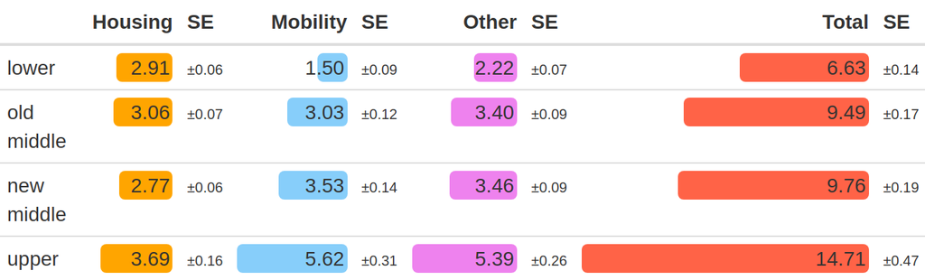

```r
export_formattable(FT,paste("highlevel","_", upper_threshold ,"up.png", sep=""))
```

T-testing of middle class differences

```r
T_full <- sapply(highlevel_codes, function(x) MIsvyttest(coicop_to_ttest_formula(x), subset(svymi, ReckwitzClass == "new middle" | ReckwitzClass == "old middle")))
T_full
```

```
##             [,1]                  [,2]                  [,3]
## statistic   -2.897606             2.497812              0.4713936
## parameter   63.1005               93.84175              100.7122
## estimate    -5.580145             9.620702              1.201303
## null.value  0                     0                     0
## alternative "two.sided"           "two.sided"           "two.sided"
## method      "Design-based t-test" "Design-based t-test" "Design-based t-test"
## data.name   character,7           character,9           character,66
## p.value     0.00516413            0.01423718            0.6383793
##             [,4]
## statistic   1.060015
## parameter   890.6629
## estimate    5.24186
## null.value  0
## alternative "two.sided"
## method      "Design-based t-test"
## data.name   character,81
## p.value     0.2894252
```

# Zoom in…

##… on Housing

```r
housing_codes <- list(coicop_to_lcf("4.4.1"), coicop_to_lcf("4.4.2"),
  setdiff(coicop_to_lcf("4"), c(coicop_to_lcf("4.4.1"), coicop_to_lcf("4.4.2"))),
  coicop_to_lcf("4"))



H_full <- sapply(housing_codes, function(x) MIcombine(with(svymi, svyby(coicop_to_ghg_formula(x), ~ReckwitzClass,svymean))))
```

```r
H <- H_full[1,] %>% simplify2array %>% as.data.frame
H_SE <- sapply(H_full[2,], function(x) sqrt(diag(x))) %>% as.data.frame


S <- (H * 52 / 1000) %>% round(digits=2)
colnames(S) <- c("Electricity", "Gas", "Other Housing", "Total")


S_SE <- (H_SE * 52 / 1000) %>% round(digits=2)
colnames(S_SE) <- c("Electricity", "Gas", "Other Housing", "Total")
S_SE <- apply(S_SE, c(1,2),function(x) paste("±", x, sep=""))


S_Form <- altbind(data.frame(S, check.names = FALSE), data.frame(S_SE, check.names = FALSE))

FT <- formattable(S_Form,
            align=c("r","l","r","l","r","l","r","l"),
            list("Electricity" = my_color_bar("orange",100),
                 "SE" = smallfont,
                 "Gas" = my_color_bar("lightskyblue",100),
                 "SE " = smallfont,
                 "Other Housing" = my_color_bar("violet",100),
                 "SE  " = smallfont,
                 "Total" = my_color_bar("tomato",100),
                 "SE   " = smallfont))


FT
```

|  | Electricity | SE | Gas | SE | Other Housing | SE | Total | SE |
| --- | --- | --- | --- | --- | --- | --- | --- | --- |
| lower | 0.77 | ±0.02 | 1.83 | ±0.05 | 0.31 | ±0.01 | 2.91 | ±0.06 |
| old middle | 0.75 | ±0.02 | 1.92 | ±0.05 | 0.39 | ±0.01 | 3.06 | ±0.07 |
| new middle | 0.66 | ±0.02 | 1.73 | ±0.06 | 0.38 | ±0.01 | 2.77 | ±0.06 |
| upper | 0.84 | ±0.04 | 2.35 | ±0.13 | 0.51 | ±0.03 | 3.69 | ±0.16 |

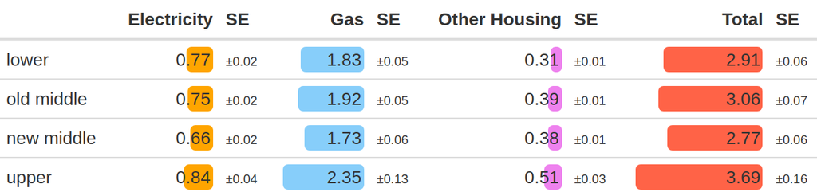

```r
export_formattable(FT,paste("housing.png", sep=""))
```

T-testing of middle class differences

```r
T_full <- sapply(housing_codes, function(x) MIsvyttest(coicop_to_ttest_formula(x), subset(svymi, ReckwitzClass == "new middle" | ReckwitzClass == "old middle")))
T_full
```

```
##             [,1]                  [,2]                  [,3]
## statistic   -3.196865             -2.347044             -0.6165247
## parameter   51.97535              105.8435              153.7875
## estimate    -1.62224              -3.734523             -0.2233822
## null.value  0                     0                     0
## alternative "two.sided"           "two.sided"           "two.sided"
## method      "Design-based t-test" "Design-based t-test" "Design-based t-test"
## data.name   character,2           character,2           character,4
## p.value     0.002365126           0.02078351            0.5384599
##             [,4]
## statistic   -2.897606
## parameter   63.1005
## estimate    -5.580145
## null.value  0
## alternative "two.sided"
## method      "Design-based t-test"
## data.name   character,7
## p.value     0.00516413
```

## … on Mobility

```r
# car_codes: "7.1." - "7.1.3.3" + "7.2." - "7.2.1.4" + "7.3.4.7" (car leasing)
# other: "7.1.3.3" + "7.2.1.4" (bicycles) + "7.3.4.4" + "7.3.4.5" (taxis and other) + "7.3.4.6" (car, van, bicycle hire)
# public transport: 7.3.1, 7.3.2, 7.3.3, 7.3.4.3(school), 7.3.4.8(water)
# air transport: 7.3.4.1, 7.3.4.2

car_codes <- setdiff(sapply(c("7.1", "7.2", "7.3.4.7"), coicop_to_lcf) %>% unlist,
                     sapply(c("7.1.3.3", "7.2.1.4"), coicop_to_lcf) %>% unlist)
pubtrans_codes <- sapply(c("7.3.1", "7.3.2", "7.3.3","7.3.4.3", "7.3.4.8"), coicop_to_lcf) %>% unlist %>% as.character

air_codes <- sapply(c("7.3.4.1", "7.3.4.2"), coicop_to_lcf) %>% unlist %>% as.character

mobility_codes <- list(car_codes, pubtrans_codes, air_codes, coicop_to_lcf(7))


H_full <- sapply(mobility_codes, function(x) MIcombine(with(svymi, svyby(coicop_to_ghg_formula(x), ~ReckwitzClass,svymean))))


H <- H_full[1,] %>% simplify2array %>% as.data.frame
H_SE <- sapply(H_full[2,], function(x) sqrt(diag(x))) %>% as.data.frame


S <- (H * 52 / 1000) %>% round(digits=2)
colnames(S) <- c("Cars", "Public", "Air", "Total")


S_SE <- (H_SE * 52 / 1000) %>% round(digits=2)
colnames(S_SE) <- c("Cars", "Public", "Air", "Total")
S_SE <- apply(S_SE, c(1,2),function(x) paste("±", x, sep=""))



internet_full <- MIcombine(with(svymi, svyby(coicop_to_ghg_formula("8.4"), ~ReckwitzClass,svymean)))
Internet <- (internet_full$coefficients * 52 / 1000) %>% round(digits=3)
internet_SE <- internet_full$variance  %>% diag %>% sqrt
internet_SE <- (internet_SE *  52 / 1000) %>% round(digits=4)
internet_SE <- sapply(internet_SE,function(x) paste("±", x, sep=""))

S_Form <- altbind(data.frame(S, Internet, check.names = FALSE), data.frame(S_SE, internet_SE))


FT <-formattable(S_Form,
            align=c("r","l","r","l","r","l","r","l"),
            list("Cars" = my_color_bar("orange",100),
                 "SE" = smallfont,
                 "Public" = my_color_bar("lightskyblue",100),
                 "SE " = smallfont,
                 "Air" = my_color_bar("violet",100),
                 "SE  " = smallfont,
                 "Total" = my_color_bar("tomato",100),
                 "SE   " = smallfont,
                 "Internet" = my_color_bar("pink",50, proportion),
                 "SE    " = smallfont))


FT
```

|  | Cars | SE | Public | SE | Air | SE | Total | SE | Internet | SE |
| --- | --- | --- | --- | --- | --- | --- | --- | --- | --- | --- |
| lower | 1.05 | ±0.05 | 0.09 | ±0.02 | 0.30 | ±0.08 | 1.50 | ±0.09 | 0.003 | ±3e-04 |
| old middle | 2.20 | ±0.07 | 0.13 | ±0.03 | 0.61 | ±0.09 | 3.03 | ±0.12 | 0.003 | ±4e-04 |
| new middle | 2.17 | ±0.07 | 0.38 | ±0.06 | 0.91 | ±0.12 | 3.53 | ±0.14 | 0.004 | ±3e-04 |
| upper | 2.94 | ±0.17 | 1.03 | ±0.18 | 1.52 | ±0.21 | 5.62 | ±0.31 | 0.006 | ±8e-04 |

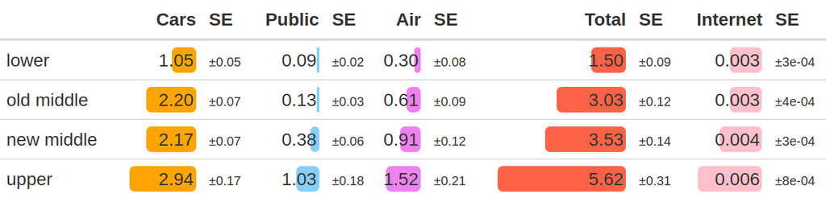

```r
export_formattable(FT,paste("mobility","_", upper_threshold ,"up.png", sep=""))
```

T-testing of middle class differences

```r
T_full <- sapply(mobility_codes, function(x) MIsvyttest(coicop_to_ttest_formula(x), subset(svymi, ReckwitzClass == "new middle" | ReckwitzClass == "old middle")))
T_full
```

```
##             [,1]                  [,2]
## statistic   -0.3397956            3.88588
## parameter   276.7472              139.0929
## estimate    -0.6396026            4.926258
## null.value  0                     0
## alternative "two.sided"           "two.sided"
## method      "Design-based t-test" "Design-based t-test"
## data.name   character,5           character,3
## p.value     0.7342682             0.0001571697
##             [,3]
## statistic   1.84198
## parameter   58.44624
## estimate    5.647731
## null.value  0
## alternative "two.sided"
## method      "Design-based t-test"
## data.name   "I((GHG_B487 + GHG_C73311t + GHG_B488 + GHG_C73312t)/A049) ~ ReckwitzClass"
## p.value     0.07055331
##             [,4]
## statistic   2.497812
## parameter   93.84175
## estimate    9.620702
## null.value  0
## alternative "two.sided"
## method      "Design-based t-test"
## data.name   character,9
## p.value     0.01423718
```

## … on Other Indirect Consumption

```r
all_consumption_codes <- setdiff(B %>% select(LCFCODE) %>% unlist %>% as.character, c(coicop_to_lcf("4"), coicop_to_lcf("7")))


meat_codes <- sapply(c("1.1.5","1.1.6", "1.1.7","1.1.8","1.1.9","1.1.10"), coicop_to_lcf) %>% unlist %>% as.character

other_food_codes <- setdiff(coicop_to_lcf(1), meat_codes)

other_consumption_codes <- setdiff(all_consumption_codes, c(meat_codes, other_food_codes, coicop_to_lcf(11))) # COICOP 11 -> Restaurants, Holidays

consumption_codes <- list(meat_codes, other_food_codes, coicop_to_lcf(11),other_consumption_codes,  all_consumption_codes) #


H_full <- sapply(consumption_codes, function(x) MIcombine(with(svymi, svyby(coicop_to_ghg_formula(x), ~ReckwitzClass,svymean))))
```

[output not shown]

[output cut: 16 more lines]

[output not shown]

```r
H <- H_full[1,] %>% simplify2array %>% as.data.frame
H_SE <- sapply(H_full[2,], function(x) sqrt(diag(x))) %>% as.data.frame


S <- (H * 52 / 1000) %>% round(digits=2)
colnames(S) <- c("Meat*", "Other Food*",  "Restaurants, Holidays*", "Miscellaneous","Total")# "Other Consumption"


S_SE <- (H_SE * 52 / 1000) %>% round(digits=2)
colnames(S_SE) <- colnames(S)
S_SE <- apply(S_SE, c(1,2),function(x) paste("±", x, sep=""))



S_Form <- altbind(S, S_SE)


FT <- formattable(S_Form,
            align=c("r","l","r","l","r","l","r","l"),
            list("Meat*" = my_color_bar("orange",200),
                 "SE" = smallfont,
                 "Other Food*" = my_color_bar("lightskyblue",200),
                 "SE " = smallfont,
                 "Restaurants, Holidays*" = my_color_bar("violet",200),
                 "SE  " = smallfont,
                 "Miscellaneous" = my_color_bar("pink",100),
                 "SE   " = smallfont,
                 "Total" = my_color_bar("tomato",100),
                 "SE    " = smallfont))

FT
```

|  | Meat* | SE | Other Food* | SE | Restaurants, Holidays* | SE | Miscellaneous | SE | Total | SE |
| --- | --- | --- | --- | --- | --- | --- | --- | --- | --- | --- |
| lower | 0.64 | ±0.02 | 0.32 | ±0.01 | 0.26 | ±0.01 | 1.00 | ±0.06 | 2.22 | ±0.07 |
| old middle | 0.83 | ±0.02 | 0.36 | ±0.01 | 0.51 | ±0.02 | 1.69 | ±0.08 | 3.40 | ±0.09 |
| new middle | 0.71 | ±0.02 | 0.36 | ±0.01 | 0.59 | ±0.02 | 1.81 | ±0.08 | 3.46 | ±0.09 |
| upper | 0.91 | ±0.05 | 0.42 | ±0.01 | 1.06 | ±0.04 | 3.00 | ±0.24 | 5.39 | ±0.26 |

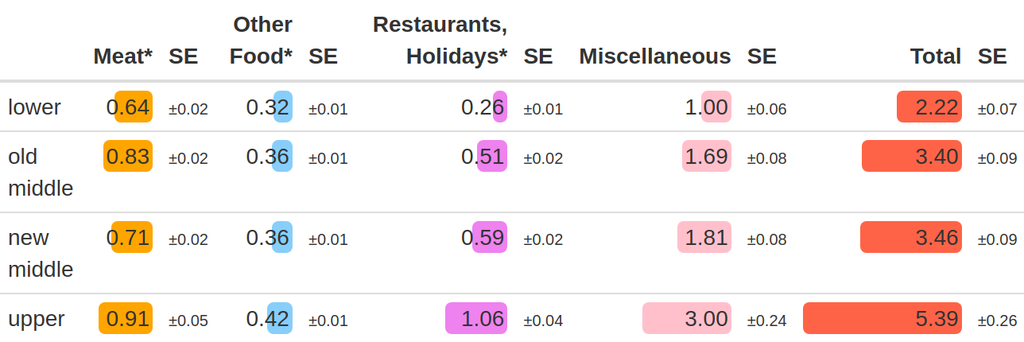

```r
export_formattable(FT,paste("consumption","_", upper_threshold ,"up.png", sep=""))
```

T-testing of middle class differences

```r
T_full <- sapply(consumption_codes, function(x) MIsvyttest(coicop_to_ttest_formula(x), subset(svymi, ReckwitzClass == "new middle" | ReckwitzClass == "old middle")))
T_full
```

```
##             [,1]                  [,2]                  [,3]
## statistic   -4.526323             -0.5246005            2.60241
## parameter   73.53854              58.56468              28.43578
## estimate    -2.315537             -0.09094336           1.377853
## null.value  0                     0                     0
## alternative "two.sided"           "two.sided"           "two.sided"
## method      "Design-based t-test" "Design-based t-test" "Design-based t-test"
## data.name   character,3           character,12          character,8
## p.value     2.264128e-05          0.6018411             0.01454395
##             [,4]                  [,5]
## statistic   0.9240303             0.4713936
## parameter   48.70212              100.7122
## estimate    2.229931              1.201303
## null.value  0                     0
## alternative "two.sided"           "two.sided"
## method      "Design-based t-test" "Design-based t-test"
## data.name   character,46          character,66
## p.value     0.3600263             0.6383793
```